# Partial fourier reconstruction and Gibbs Ringing

```python
import BrukerMRI as bruker
import pylab as pl
import plot
#Python method of extracting raw Bruker Files
import BrukerMRI as bruker

# Modules
import pandas as pd
import pydicom as dcm
import math
import numpy as np
import matplotlib.pyplot as plt
import glob
from os.path import expanduser
import os
from matplotlib import cm
import cmath
```

```python
from phantominator import shepp_logan
# MR phantom (returns proton density, T1, and T2 maps)
M0, T1, T2 = shepp_logan((128, 128,20), MR=True)
```

```python
def i_plots(i_spaces):
    key_list = list(i_spaces)
    plt.figure(figsize=(25,25))
     #plt.rc('font', size=SMALL_SIZE)          # controls default text sizes
    plt.rc('axes', titlesize=SMALL_SIZE)     # fontsize of the axes title
    plt.rc('axes', labelsize=MEDIUM_SIZE)    # fontsize of the x and y labels
    plt.rc('xtick', labelsize=SMALL_SIZE)    # fontsize of the tick labels
    plt.rc('ytick', labelsize=SMALL_SIZE)    # fontsize of the tick labels
    plt.rc('legend', fontsize=SMALL_SIZE)    # legend fontsize
    plt.rc('figure', titlesize=BIGGER_SIZE)  # fontsize of the figure title

    plt.rcParams['text.color'] = COLOR
    plt.rcParams['axes.labelcolor'] = COLOR
    plt.rcParams['xtick.color'] = COLOR
    plt.rcParams['ytick.color'] = COLOR

    for key,value in i_spaces.items():
        plt.subplot(((300+21+key_list.index(key))))
        plt.imshow((value[:,:]))
        plt.title('Image of ' + key)
        plt.colorbar()
```

## Phantom

### Applying a Phase to a Real Image

```python
nx = 128
[x,y,z] = np.meshgrid(range(0,nx),range(0,nx),range(0,20))
phase = np.sqrt(np.power((x-nx/4)/5,2) + np.power((y-nx/6)/10,2))
phase.shape
```

```
(128, 128, 20)
```

```python
M1 = M0.copy()
M1_phased = M1 * np.exp(1j*phase)
```

### Selecting a Single Slice

```python
# imgPF is M1_phased_6
M1_phased_6 = M1_phased[:,:,6]
mag = np.abs(M1_phased_6)
ang = np.angle(M1_phased_6)
real = np.real(M1_phased_6)
imaginary = np.imag(M1_phased_6)

## Obtaining low resolution
mag_lr = mag.copy()
mag_lr[mag_lr < 0.01] = 0
mag_mult_phase = ang*mag_lr
```

## Sample Data and Generate a Low-Resolution Phase Estimate

```python
def partial_fourier(k_sp,upper_or_lower,percentage):
    k_space = k_sp.copy()
    frac = percentage/100
    k_sp_frac = np.empty(k_sp.shape,dtype ='complex')
    start = 0
    end = 0

    if upper_or_lower == "up":
        start = 0
        end = int(frac*(int(k_space.shape[0])))

    elif upper_or_lower == "lower":
        start = k_space.shape[0]-int(frac*(int(k_space.shape[0])))
        end = k_space.shape[0]

    for i in range(start,end):
        k_sp_frac[i,:] = k_space[i,:]

    return k_sp_frac
```

```python
def zero_fill(k_sp,upper_or_lower,percentage):
    k_space = k_sp.copy()
    frac = percentage/100
    k_sp_frac = np.zeros(k_sp.shape,dtype ='complex')
    start = 0
    end = 0

    if upper_or_lower == "up":
        start = 0
        end = int(frac*(int(k_space.shape[0])))

    elif upper_or_lower == "lower":
        start = k_space.shape[0]-int(frac*(int(k_space.shape[0])))
        end = k_space.shape[0]

    for i in range(start,end):
        k_sp_frac[i,:] = k_space[i,:]

    return k_sp_frac
```

### K-Space of Phased Image, M1_Phased

```python
def img_diff(corrected,original):
    c = np.abs(np.abs(corrected) - np.abs(original))
    return c
```

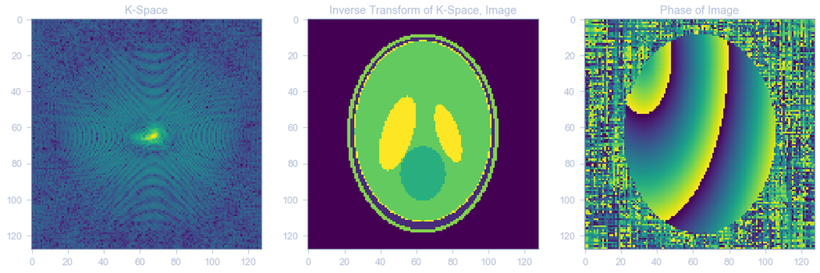

```python
M1_ksp_single = np.fft.fftshift(np.fft.fft2(M1_phased_6),(0,1))
M1_rec = np.fft.ifft2(np.fft.fftshift(M1_ksp_single,(0,1)))


plt.figure(figsize=(18,18))

plt.subplot(131)
plt.imshow(np.log(1+np.abs(M1_ksp_single)))
plt.title('K-Space')

plt.subplot(132)
plt.imshow(np.abs(M1_rec))
plt.title('Inverse Transform of K-Space, Image')

plt.subplot(133)
plt.imshow(np.angle(M1_rec))
plt.title('Phase of Image')
```

## Algorithm 1: Zero Filling

```python
M1_zero = zero_fill(M1_ksp_single,'up',75)
```

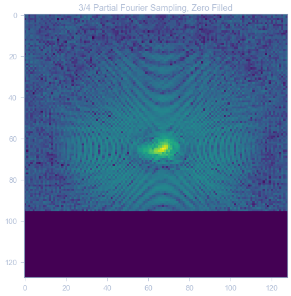

```python
plt.figure(figsize=(8,8))
plt.imshow(np.log(1+np.abs(M1_zero)))
plt.title('3/4 Partial Fourier Sampling, Zero Filled')
```

```python
img_zero = np.fft.ifft2(np.fft.fftshift(M1_zero,(0,1)))
img_diff_algo1 = img_diff(img_zero,M1_phased_6)
```

### Image of Zero Filled K-space

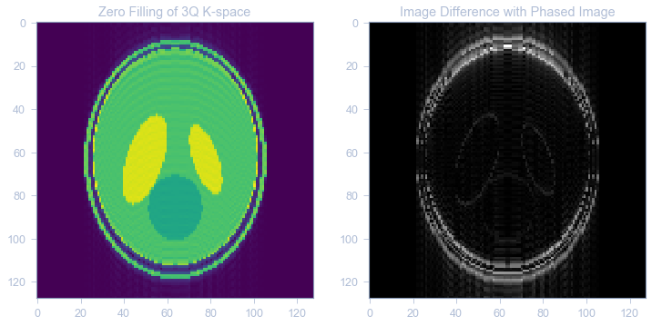

```python
plt.figure(figsize = (12,12))

plt.subplot(121)
plt.imshow(np.abs(img_zero))
plt.title('Zero Filling of 3Q K-space')


plt.subplot(122)
plt.imshow(10*img_diff_algo1, cmap='gray')
plt.title('Image Difference with Phased Image')
```

### **Apodization**

Gibbs artifacts occur as a consequence of using Fourier transforms to reconstruct MR signals into images. In theory, any signal can be represented as an infinite summation of sine waves of different amplitudes, phases, and frequencies. In MR imaging, however, we are restricted to sampling a finite number of frequencies and must therefore approximate the image by using only a relatively few harmonics in its Fourier representation. The Fourier series, then, is cut short or truncated, hence the name for this artifact.

In Partial Fourier acquisitions, high frequency signals which provide the details and edges of the image are lost and a sharp transition of high frequency signal to 0 causes the ringing artifact.

```python
# Column data from center of K-space
M1_ksp_3Q = partial_fourier(M1_ksp_single,'up',75)
img_3Q = np.fft.ifft2(np.fft.fftshift(M1_zero,(0,1)))
gibbs = M1_ksp_3Q[0:128,65]
```

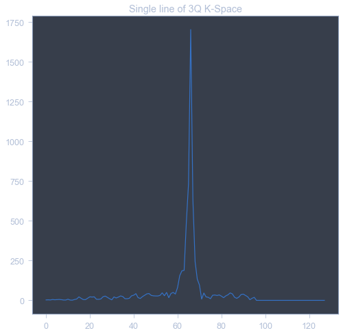

```python
plt.figure(figsize=(8,8))
plt.plot(np.abs(gibbs))
plt.title('Single line of 3Q K-Space')
```

To prevent Gibbs ringing, k-space may be apodized/filtered prior to reconstruction to more smoothly transition from sampled k-space to zero.

- an optical filtering technique.
- It is the technical term for changing the shape of a mathematical function, an electrical signal, an optical transmission or a mechanical structure
- The term apodization is used frequently in publications on Fourier-transform infrared (FTIR) signal processing.

The term apodization is used frequently in publications on Fourier-transform infrared (FTIR) signal processing. Examples of apodization used in the fast Fourier transform analyzer to smooth the discontinuities at the beginning and end of the sampled time record are:

- 1.3.2.1 Apodizing filter
- 1.3.2.2 Hann window

#### Apodizing filter

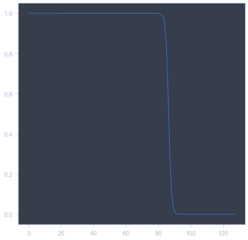

```python
x = np.linspace(-102,48,128)
W = 1/(1+np.conj(np.transpose(np.exp(x)))/1)
plt.figure(figsize=(8,8))
plt.plot(W)
```

##### Multiplying K-Space and Filter in 1D

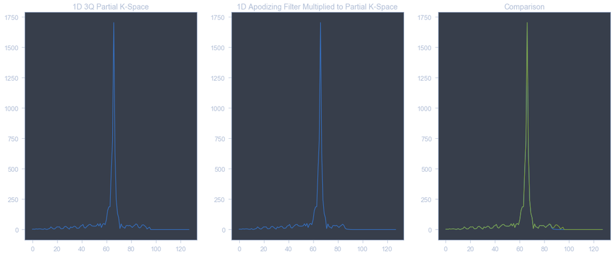

```python
k3_a_1d = gibbs*W

plt.figure(figsize=(20,8))

plt.subplot(131)
plt.plot(np.abs(gibbs))
plt.title("1D 3Q Partial K-Space")

plt.subplot(132)
plt.plot(np.abs(k3_a_1d))
plt.title("1D Apodizing Filter Multiplied to Partial K-Space")

plt.subplot(133)
plt.plot(np.abs(k3_a_1d))
plt.plot(np.abs(gibbs))
plt.title("Comparison")
```

##### Multiplying K-Space and Filter 2D

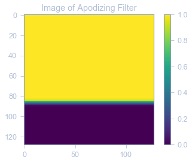

```python
x_a = np.linspace(-102,48,128)
y_a = np.linspace(0,128,128)
xv_a, yv_a = np.meshgrid(x_a,y_a)
apo_filter = 1/(1+np.conj(np.transpose(np.exp(xv_a)))/1)

plt.imshow(apo_filter)
plt.colorbar()
plt.title('Image of Apodizing Filter')
```

```python
phs1 = np.zeros(M1_ksp_3Q.shape, dtype = 'complex')
phs1[:,:] = M1_ksp_3Q[:,:]*apo_filter[:,:]
img_3Q_apo = np.fft.ifft2(np.fft.fftshift(phs1,(0,1)))
img_diff_algo1_filter = img_diff(img_3Q_apo,M1_phased_6)
```

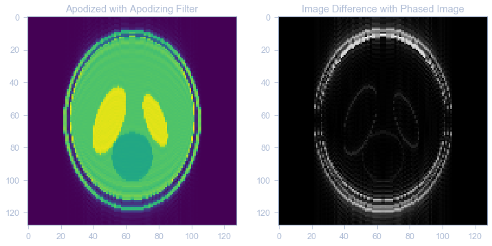

```python
plt.figure(figsize = (12,12))

plt.subplot(121)
plt.imshow(np.abs(img_3Q_apo))
plt.title('Apodized with Apodizing Filter')


plt.subplot(122)
plt.imshow(10*img_diff_algo1_filter,cmap = 'gray')
plt.title('Image Difference with Phased Image')
```

#### Hanning Function

- Another example of apodization is the use of the Hann window in the fast Fourier transform analyzer to smooth the discontinuities at the beginning and end of the sampled time record.

```python
N_x = M1_ksp_3Q.shape[1]
N_y = 128
x = np.linspace(0,N_x,N_x)
y = np.linspace(0,N_y,N_y)
xv, yv = np.meshgrid(x, y)
hanning = 0.5*(1-np.cos(2*np.pi*(yv)/(N_y-1)))
```

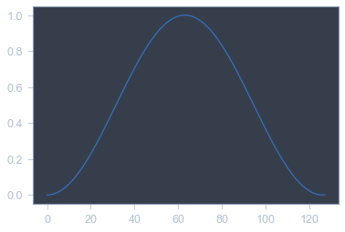

```python
plt.plot(hanning[:,0])
```

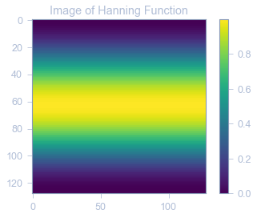

```python
plt.imshow(hanning)
plt.colorbar()
plt.title('Image of Hanning Function')
```

### Convolving Apodizing Filter and Hanning Function

Given that the images still produce Gibbs ringing, the Hanning function is used to smoothen the Apodizing filter to further smooth the discontinuities at the beginning and end of the sampled time record.

##### Convolving in 1D

```python
#ones = np.ones((128,1))
#gaussian = ones*window
apo = apo_filter[:,0]
hann = hanning[:,0]
```

```python
padded_apo = np.concatenate((np.ones((64,))*apo[0],apo,np.ones((64,))*apo[apo.shape[0]-1]))
padded_hann = np.concatenate((np.ones((64,))*hann[0],hann,np.ones((64,))*hann[hann.shape[0]-1]))

apo_hann_1d = np.convolve(padded_apo,padded_hann,mode='same')
ah_1d = apo_hann_1d[64:192]
ah = np.reshape(ah_1d,(128,1))
```

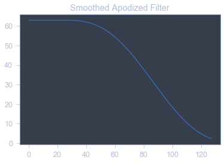

```python
plt.plot(ah)
plt.title('Smoothed Apodized Filter')
```

```python
gibbs_resh = np.reshape(gibbs.copy(),(128,1))
```

```python
k3_ah_1d = gibbs_resh*ah
```

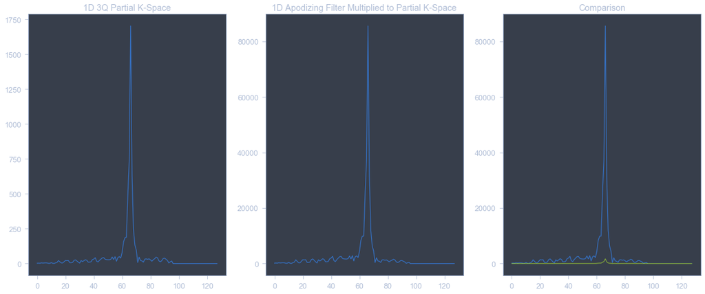

```python
plt.figure(figsize=(20,8))

plt.subplot(131)
plt.plot(np.abs(gibbs))
plt.title("1D 3Q Partial K-Space")

plt.subplot(132)
plt.plot(np.abs(k3_ah_1d))
plt.title("1D Apodizing Filter Multiplied to Partial K-Space")

plt.subplot(133)
plt.plot(np.abs(k3_ah_1d))
plt.plot(np.abs(gibbs))
plt.title("Comparison")
```

#### Multiplying K-Space and Smoothed Apodized Filter 2D

```python
ah_ones = np.ones((128,128),'complex')
filter_hann = ah_ones*ah
```

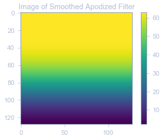

```python
plt.imshow(np.abs(filter_hann))
plt.colorbar()
plt.title('Image of Smoothed Apodized Filter')
```

```python
phs3 = np.zeros(M1_ksp_3Q.shape, dtype = 'complex')
phs3[:,:]= M1_ksp_3Q[:,:]*filter_hann[:,:]
img_3Q_filt_hann = np.fft.ifft2(np.fft.fftshift(phs3,(0,1)))
img_diff_algo1_filt_hann = img_diff(img_3Q_filt_hann,img_3Q_apo)
```

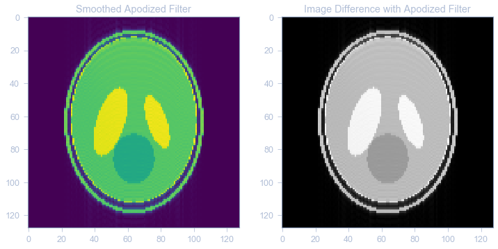

```python
plt.figure(figsize = (12,12))

plt.subplot(121)
plt.imshow(np.abs(img_3Q_filt_hann))
plt.title('Smoothed Apodized Filter')

plt.subplot(122)
plt.imshow(10*img_diff_algo1_filt_hann,cmap = 'gray')
plt.title('Image Difference with Apodized Filter')
```

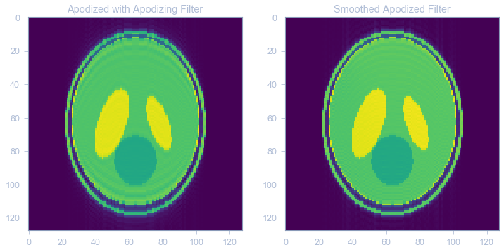

```python
plt.figure(figsize = (12,10))

plt.subplot(121)
plt.imshow(np.abs(img_3Q_apo))
plt.title('Apodized with Apodizing Filter')

plt.subplot(122)
plt.imshow(np.abs(img_3Q_filt_hann))
plt.title('Smoothed Apodized Filter')
```

### Apodizing in Image Space

#### Convolution of Image and FT Transformed Apodizing Filter

```python
ft_af = np.fft.fftshift(np.fft.ifft2(np.fft.fftshift(apo_filter)))
ft_af_one = ft_af[65,:]
img_one = img_3Q[:,65]

img_conv_ft_apo_1d = np.convolve(img_one,ft_af_one,mode='same')
ica2 = np.reshape(img_conv_ft_apo_1d,(128,1))
```

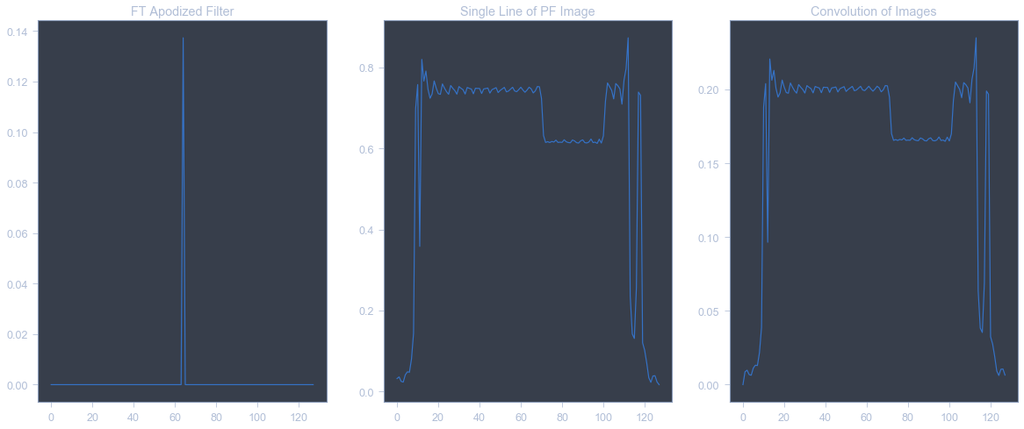

```python
plt.figure(figsize=(20,8))

plt.subplot(131)
plt.plot(ft_af_one)
plt.title("FT Apodized Filter")

plt.subplot(132)
plt.plot(np.abs(img_one))
plt.title("Single Line of PF Image")

plt.subplot(133)
plt.plot(np.abs(ica2))
plt.title("Convolution of Images")
```

##### Fourier Transform of Apo filter in 2D

```python
from scipy import signal

img_conv_apo = signal.convolve2d(ft_af,img_3Q,mode='same')#, boundary='fill',fillvalue=0)
```

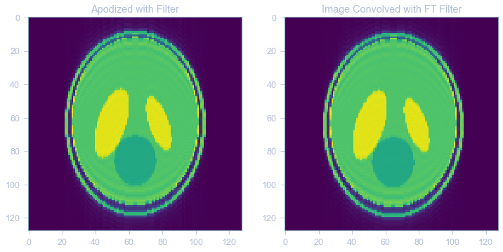

```python
plt.figure(figsize = (12,12))

plt.subplot(121)
plt.imshow(np.abs(img_3Q_apo))
plt.title('Apodized with Filter')

plt.subplot(122)
#plt.imshow(10*img_diff_img,cmap = 'gray')
plt.imshow(np.abs(img_conv_apo))
plt.title('Image Convolved with FT Filter')
#plt.title('Image Difference of Convolved and Multiplied')
```

#### Convolution of Image and FT Transformed Smoothed Apodizing Filter

```python
ft_ah = np.fft.fftshift(np.fft.ifft2(np.fft.fftshift(filter_hann)))
```

```python
from scipy import signal

img_conv_ah = signal.convolve2d(ft_ah,img_3Q,mode='same')#, boundary='fill',fillvalue=0)
```

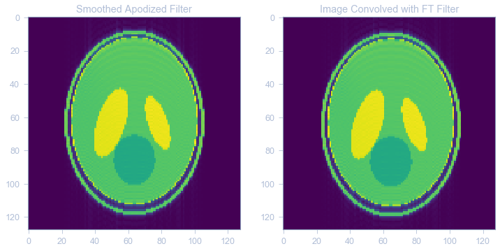

```python
plt.figure(figsize = (12,12))

plt.subplot(121)
plt.imshow(np.abs(img_3Q_filt_hann))
plt.title('Smoothed Apodized Filter')

plt.subplot(122)
#plt.imshow(10*img_diff_img,cmap = 'gray')
plt.imshow(np.abs(img_conv_ah))
plt.title('Image Convolved with FT Filter')
#plt.title('Image Difference of Convolved and Multiplied')
```

## Algorithm 2 - Conjugate Synthesis

```python
def hermitian_symmetry(k_space):

    # identifying missing points of k-space
    # checks for pints with missing information
    # replaces points with conjugate symmetry based on corresponding points

    #check shape
    k_sp = k_space.copy()
    shape = k_sp.shape
    row = int(shape[0])
    mid_row = int(row/2)


    for i in range(0,mid_row):
        if all(k_sp[i,:] == ((0+0*1j))):
           k_sp[i,:] = np.conj(np.flip(k_sp[row-i,:]))

    for k in range(0,mid_row):
        if all(k_sp[mid_row+k,:] == ((0+0*1j))):
           k_sp[mid_row+k,:] = np.conj(np.flip(k_sp[row-(mid_row+k),:]))

    return k_sp
```

- One defining feature of Partial Fourier reconstructions is the use of the fact that when your image is purely real (or equivalently, you know the image phase)
- To get the missing entry, we can simply look at the value in the mirror-symmetric position opposite the origin (A), and conjugate its value to get (A*).
- In most cases, Partial Fourier is performed along one axis, and the other axis can be fully reconstructed via inverse Fourier Transform, which results in a bunch of independent 1D problems anyway.
- Let's see what happens when we naively use the conjugate symmetry principle on data that doesn't actually satisfy the constraint of being purely real:

```python
ksp_3Q_pf = hermitian_symmetry(M1_ksp_3Q)
```

```python
img_3Q_pf = np.fft.ifft2(np.fft.fftshift(ksp_3Q_pf,(0,1)))
img_diff_algo2 = img_diff(img_3Q_pf,M1_phased_6)
```

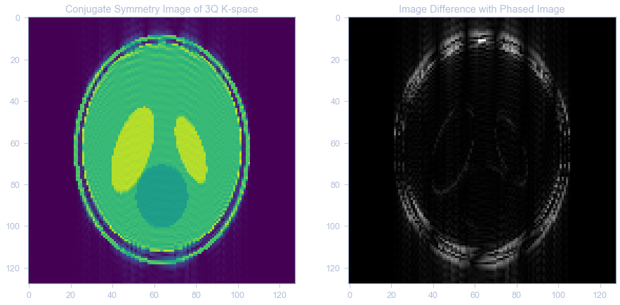

```python
plt.figure(figsize = (15,15))

plt.subplot(121)
plt.imshow(np.abs(img_3Q_pf))
plt.title('Conjugate Symmetry Image of 3Q K-space')


plt.subplot(122)
plt.imshow(img_diff_algo2,cmap = 'gray')
plt.title('Image Difference with Phased Image')
```

## Algorithm 3 - Homodyne/Margosian

Without ensuring the image is real, synthesizing conjugate signals from the symmetric locations in k-space clearly produces poor results. In fact, conjugate synthesis without using the phase results in worse reconstruction than zero-filling.

### Hanning Function

#### Phase Estimate

```python
up = int(nx/2-10)
low = int(nx/2+10)
centre_PFksp = M1_ksp_3Q[up:low,:]
phs = np.zeros(M1_ksp_3Q.shape, dtype = 'complex')
phs[up:low,:] = centre_PFksp*hanning[up:low,:]
phs2 = np.exp(1j*np.angle((np.fft.ifft2(np.fft.ifftshift(phs)))))
```

```python
ksp_phs_corr = M1_ksp_3Q*np.conj(phs2)
img_phs_corr = np.fft.ifft2(np.fft.fftshift(ksp_phs_corr,(0,1)))
```

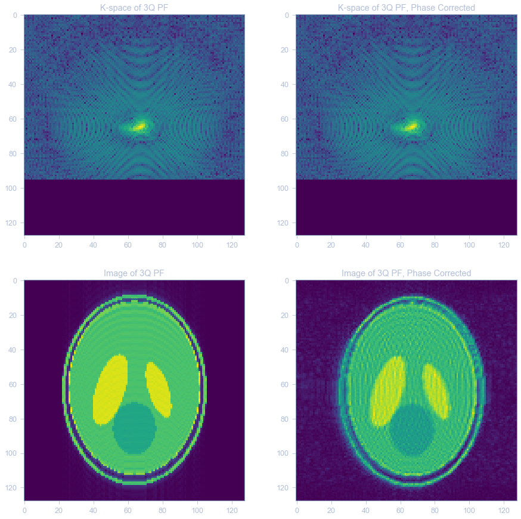

```python
plt.figure(figsize=(15,15))

plt.subplot(221)
plt.imshow(np.log(1+np.abs(M1_ksp_3Q)))
plt.title('K-space of 3Q PF')

plt.subplot(222)
plt.imshow(np.log(1+np.abs(ksp_phs_corr)))
plt.title('K-space of 3Q PF, Phase Corrected')

plt.subplot(223)
plt.imshow(np.abs(img_3Q))
plt.title('Image of 3Q PF')

plt.subplot(224)
plt.imshow(np.abs(img_phs_corr))
plt.title('Image of 3Q PF, Phase Corrected')
```

### 1 Re-weighting of Sample

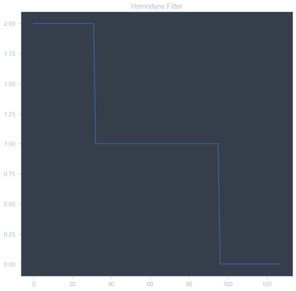

```python
# generate re-weighting vector
filt = np.zeros((128,1))
filt[0:32,:] = 2 # Low
filt[32:96,:] = 1;     # High

plt.figure(figsize=(10,10))
plt.plot(filt)
plt.title('Homodyne Filter')
```

```python
reweighted_ksp_3Q = M1_ksp_3Q*filt
```

### 2 Inverse Fourier transforming the re-weighted k-space¶

```python
#img_rw = np.fft.fftshift(np.fft.ifft2(np.fft.fftshift(reweighted_ksp_3Q)))
img_rw = np.fft.ifft2(np.fft.fftshift(reweighted_ksp_3Q,(0,1)))
```

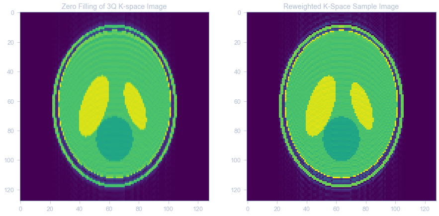

```python
plt.figure(figsize=(15,15))

plt.subplot(121)
plt.imshow(np.abs(img_3Q))
plt.title('Zero Filling of 3Q K-space Image')

plt.subplot(122)
plt.imshow(np.abs(img_rw))
plt.title('Reweighted K-Space Sample Image')
```

### 3 Phase Correction of re-weighted k-space Image

```python
#ksp_homodyne = np.conj(phs2)*reweighted_ksp_3Q
#img_homodyne = np.fft.fftshift(np.fft.ifft2(ksp_homodyne))
img_homodyne = img_rw*np.conj(phs2)
```

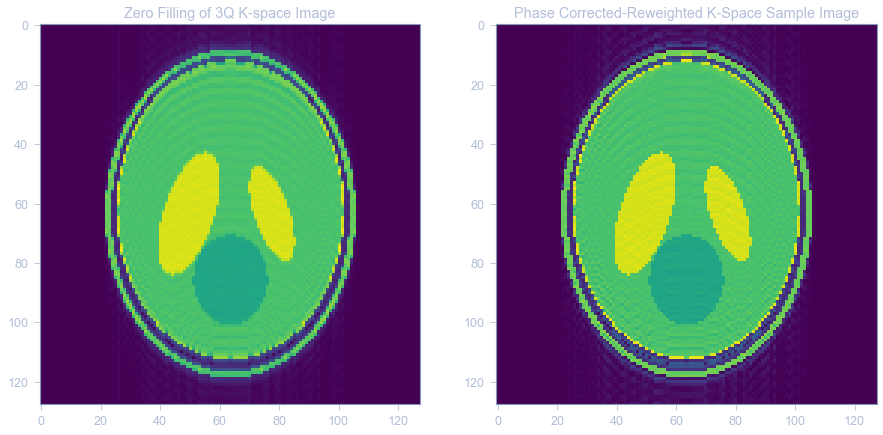

```python
plt.figure(figsize=(15,15))

plt.subplot(121)
plt.imshow(np.abs(img_3Q))
plt.title('Zero Filling of 3Q K-space Image')

plt.subplot(122)
plt.imshow(np.abs(img_homodyne))
plt.title('Phase Corrected-Reweighted K-Space Sample Image')
```